# 11747_2014_400_Article 768..789

Converted from PDF `Habel-DownsizingCustomerReactions-2015-JAMS.pdf` · 22 pages · anchors: page `#pN`, block `#pN-bK`

Page 1

ORIGINAL EMPIRICAL RESEARCH

## Customer reactions to downsizing: when and how is satisfaction affected?

Johannes Habel & Martin Klarmann

Received: 18 May 2013 /Accepted: 14 July 2014 /Published online: 19 August 2014 # Academy of Marketing Science 2014

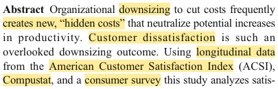

NOTE: figure/graphic rendered as an image from the PDF; its content is not machine-readable text. Caption (if any) follows as the next block.

Abstract Organizational downsizing to cut costs frequently creates new, “hidden costs” that neutralize potential increases in productivity. Customer dissatisfaction is such an overlooked downsizing outcome. Using longitudinal data from the American Customer Satisfaction Index (ACSI), Compustat, and a consumer survey this study analyzes satisfaction outcomes of downsizing. It extends research in this domain to B2C markets and explicitly addresses environmental influences on the downsizing–satisfaction link. Results indicate that there is a negative effect of downsizing on customer satisfaction. It is particularly pronounced for companies (1) with little organizational slack, (2) with high labor productivity, or (3) in industries with high R&D intensity. Moreover, downsizing has a stronger negative impact on customer satisfaction in product categories with (4) high risk importance and (5) low probability for consumer errors as well as (6) low level of brand consciousness. Furthermore, customer satisfaction mediates the effect of downsizing on financial performance. The results provide an explanation for

why so many downsizing projects fail and what managers can do to prevent adverse effects of downsizing on customer satisfaction and financial performance.

Keywords Customer satisfaction <sup>.</sup>Organizational downsizing <sup>.</sup>Firm performance <sup>.</sup>Panel data analysis

Introduction

In a “Group Strategy Update,” Australian airline Qantas announced on February 26, 2014, plans to cut 5,000 jobs (Qantas 2014). In the same week, the Financial Times reported plans that IBM was to reduce its U.S. workforce by 13,000 to 15,000 employees (Waters 2014). Hence, downsizing continues to be one of the most appealing cost-cutting strategies to firms worldwide. Firms typically expect that the layoffs will improve financial performance. For instance, Qantas (2014) explicitly states in their media release that the “long-term goal” of the cost reductions is “the transformation of the Qantas Group for profitable, sustainable growth.”

The importance of downsizing in business practice has motivated many academic studies. In a comprehensive review, Datta et al. (2010) identify four major research streams. Two of them look at environmental and organizational antecedents of downsizing. The other two address its consequences. Of the streams addressing the consequences of downsizing, the first looks at organizational outcomes. Chadwick, Hunter, and Walston (2004, p. 406) summarize: “The general consensus among researchers over the last two decades is that organizational performance is as likely to suffer as it is to improve after downsizing.” The second addresses outcomes at the employee level. Here, Datta et al. (2010, p. 307) conclude that “[d]ownsizing has a significant potential to … disrupt relationship networks, and destroy the trust and loyalty that binds employees and their employers.”

Article note The authors wish to thank Martin Artz, Christian Homburg, Sabine Staritz, participants of the AMA Summer Marketing Educators’ Conference 2012 in Chicago, participants of the second German-French Customer Empowerment workshop 2013 at the Karlsruhe Institute of Technology (KIT), as well as the three anonymous reviewers and Tomas Hult for their valuable insights and comments on earlier drafts of the manuscript.

J. Habel ESMT European School of Management and Technology, Berlin, Germany

M. Klarmann (*) Institute of Information Systems and Marketing (IISM) at the Karlsruhe Institute of Technology (KIT), Zirkel 2, Building 20.21, Room 104, 76131 Karlsruhe, Germany e-mail: martin.klarmann@kit.edu

J. Habel Ruhr-University Bochum, Bochum, Germany

J. of the Acad. Mark. Sci. (2015) 43:768–789 DOI 10.1007/s11747-014-0400-y

Page 2

Interestingly, despite Cascio’s (2005, p.45) advice to “think through the potential consequences of restructuring on customers,” in their review Datta et al. (2010) identify only two papers that examine the effect of downsizing on customers (out of a total of 91). Recently, more research has been conducted in the area. For example, Subramony and Holtom (2012) report that downsizing reduces customer orientation, which translates into a negative effect on customers’ brand perceptions. However, the focus of research lies on the effect of downsizing on customer satisfaction. Table 1 provides an overview.

As shown in Table 1, researchers consistently report negative effects of downsizing on customer satisfaction. That being said, most evidence comes from B2B samples (Lewin 2009; Lewin and Johnston 2008; Lewin et al. 2010; Williams et al. 2011) or samples with a prominent B2B share (Homburg et al. 2012; Wagar 1998). One is from the financial services sector (McElroy et al. 2001).

Hence, previous research in the area is almost exclusively based on environments where personal interaction between employees and customers is important. Here, the internal disruption caused by downsizing will be a particular threat to delivering quality. Through processes

like emotional contagion (e.g., Henning-Thurau et al. 2006), negative job satisfaction outcomes may translate into negative customer satisfaction (e.g., Homburg and Stock 2004). However, elsewhere the relationship may be much more complex. While pointing to personal interaction as differentiator, Anderson et al. (1997) find that productivity improvements (which can be achieved through downsizing) are negatively related to customer satisfaction for services, but positively related for manufactured goods. Homburg et al. (2012) find that customer uncertainty following downsizing is much larger if customers interact frequently with their contact employees from the downsizing firm.

We are interested whether the negative effect of downsizing on customer satisfaction generalizes to other contexts. For our sample we draw on American Customer Satisfaction Index (ACSI) data, which is collected for many product categories (e.g., food, appliances, apparel, internet services, cars), where customers interact less with firm employees. We argue that in the industries covered by the ACSI, the effect of downsizing on customer satisfaction is far less intuitive than in B2B environments. In particular, we expect that the degree to which employees

Table 1 Literature on the effect of downsizing on customer satisfaction

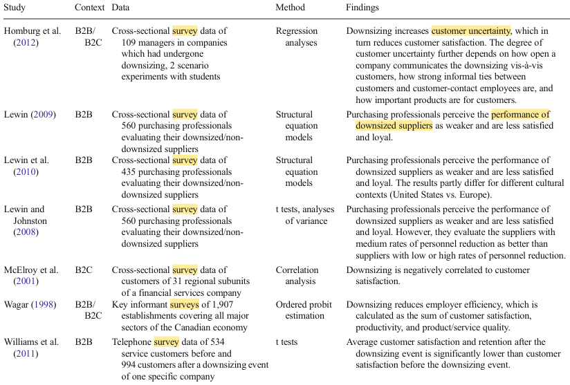

NOTE: complex table shown as an image of the PDF; the text below is a rough machine extraction and may be mis-aligned.

**extracted text (unreliable layout)**

J. of the Acad. Mark. Sci. (2015) 43:768–789 769

Page 3

are a crucial resource to the downsizing firm will affect the downsizing–satisfaction link. For instance, if the firm has enough excess resources (“organizational slack,” Love and Nohria 2005), product quality is less likely to suffer through downsizing and customers might even benefit from reduced prices. Hence, customer satisfaction might not be negatively affected by downsizing. To account for effects like this we analyze measures of the downsizing firm’s resources as moderators of the downsizing–satisfaction link.

Moreover, whether customers respond negatively to downsizing will also depend on what they learn of the downsizing (Homburg et al. 2012). Only if they devote a certain amount of time and attention to a product category might they notice quality deficiencies resulting from downsizing. Likewise, for signaling effects (Love and Kraatz 2009) as well as reputational effects of downsizing (Flanagan and O’Shaughnessy 2005; Zyglidopoulos 2005) to affect satisfaction, typically requires that customers follow the business press. To account for these effects, we analyze customers’ product category involvement and customers’ purchase criteria as moderators of the downsizing–satisfaction link.

Finally, we are interested whether customer outcomes to downsizing require firms to reconsider downsizing as a management instrument. Therefore, we link customer satisfaction after downsizing to firm performance.

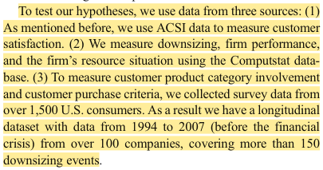

NOTE: figure/graphic rendered as an image from the PDF; its content is not machine-readable text. Caption (if any) follows as the next block.

**text found inside the figure**

To test our hypotheses, we use data from three sources: (1) As mentioned before, we use ACSI data to measure customer satisfaction. (2) We measure downsizing, firm performance, and the firm’s resource situation using the Computstat database. (3) To measure customer product category involvement and customer purchase criteria, we collected survey data from over 1,500 U.S. consumers. As a result we have a longitudinal dataset with data from 1994 to 2007 (before the financial crisis) from over 100 companies, covering more than 150 downsizing events.

Our research makes at least four contributions to the discipline. First, we extend research on customer responses to downsizing from contexts with much employee–customer interaction to less interactive B2C environments. Second, we identify environmental conditions related to the downsizing firm’s resources and customer information processing that determine whether downsizing has a negative impact on customer satisfaction. Thus, we facilitate predictions regarding potential problems resulting from downsizing. Third, by employing longitudinal data, our study addresses causality issues. Previous findings on satisfaction outcomes to downsizing come almost invariably from cross-sectional designs. Fourth, by linking customer responses to downsizing with financial performance, our study improves the understanding of the ambiguous results on

performance implications of downsizing. If customer outcomes depend on contextual factors, this helps understand mixed performance effects of earlier research.

Conceptual framework

Figure 1 depicts our conceptual framework. It is a causal chain leading from downsizing via customer satisfaction to financial performance. Twelve contextual factors moderate the link between downsizing and customer satisfaction.

We define downsizing as major workforce reductions to cut costs and to improve productivity and consequently financial performance (Freeman and Cameron 1993). The typical rationale behind downsizing is to maintain output levels in terms of product and service quality while using less input—that is, labor—thereby cutting costs. However, as companies may find it difficult to maintain quality levels after downsizing, it could affect customer satisfaction, defined as a “cumulative evaluation of a firm’s market offering” (Fornell et al. 1996, p. 8).

A key conceptual idea behind this paper is that the relationship between downsizing and customer satisfaction may not always be negative. In environments where customer interaction with firm employees is not common, we expect that two types of contextual factors influence the downsizing–satisfaction link: (1) variables relating to the resources of the firm and (2) variables related to consumer information processing in the buying process. Overall, we expect that downsizing’s negative effect on customer satisfaction will depend on the degree to which the downsized employees are crucial in line with the resource-based view of the firm (Kozlenkova et al. 2014). And in particular, we expect that downsizing’s negative effect on customer satisfaction will depend on the degree to which customers can perceive the downsizing and believe it to be important information.

Concerning the downsizing firm’s resources, we consider two sets of variables. The first consists of measures of a company’s resource dependency. Prior downsizing research has identified three key factors in this regard: (1) Firms can shield themselves against disruptions of their resources through organizational slack, defined as “resources in excess of those required to produce necessary outputs” (Love and Nohria 2005, p. 1087). (2) Negative downsizing outcomes are more likely if a firm’s labor productivity, defined as the amount of output per unit of labor (Koch and McGrath 1996), is high. (3) Firms are particularly affected by negative affect in the workforce if they depend on innovation. This is captured by industry R&D

770 J. of the Acad. Mark. Sci. (2015) 43:768–789

Page 4

intensity, defined as average firm expenditures for research and development in an industry (Guthrie and Datta 2008).

The second set of resource-related variables concerns the company’s resource history. A key concept of the resource-based view is path dependence (Vergne and Durand 2010). It posits that history is an important factor driving the outcome of firm decisions (Sydow et al. 2009)—or, in other words, “history matters” (Vergne and Durand 2010, p. 741).

Building on the concept of path dependence, we argue that the effect of downsizing on customer satisfaction depends on at least two past events. First, we include prior downsizing, defined as the occurrence of another major workforce reduction that took place before the downsizing. Second, we include prior losses, defined as negative earnings before interest and taxes in the year prior to the downsizing.

Concerning consumer information processing, we also consider two sets of variables. The first set consists of different aspects of customers’ product category involvement, as “depending on their level of involvement, individual consumers differ in the extent of their decision process and their search for information” (Laurent and Kapferer 1985, p. 41). Drawing on Laurent and Kapferer’s (1985, Kapferer and Laurent 1993) original scale, we distinguish five dimensions of involvement: (1) a customer’s interest in a product category; (2) hedonic

product value, i.e., a customer’s perception that a product category provides pleasure; (3) sign product value, i.e., a customer’s perception that a product expresses his or her self; (4) risk importance, i.e., a customer’s perception that a poor product choice leads to negative consequences; and (5) probability of error, i.e., a customer’s perception that making a poor product choice is likely.

The second set of consumer-related variables comprises customers’ purchase criteria. Whether the disruption of firm resources after downsizing affects customer satisfaction should depend on what drives customer purchase decisions. We propose that two criteria are of particular relevance in this respect: service consciousness, which denotes to what extent customers place value on services vs. goods in a product category, and brand consciousness, which we define as the extent to which customers place value on brands in a product category.

Lastly, customer satisfaction is modeled as driver of company’s financial performance. It is defined as the monetary return a company yields on its invested capital.

Hypotheses

As mentioned before, prior research has established that on average, customer satisfaction decreases after downsizing (e.g., Homburg et al. 2012; Lewin et al. 2010). Therefore,

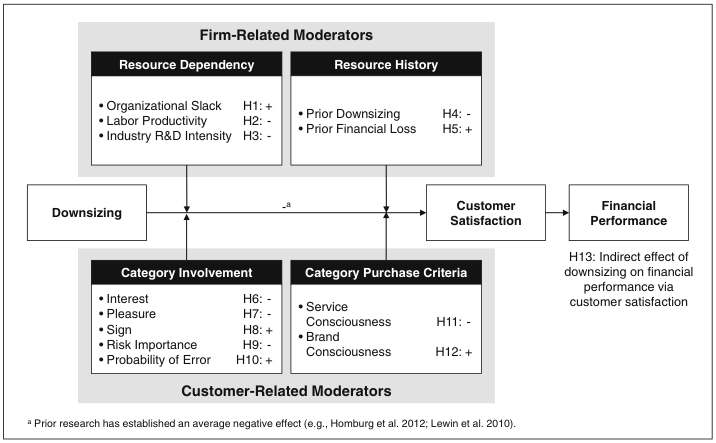

NOTE: figure/graphic rendered as an image from the PDF; its content is not machine-readable text. Caption (if any) follows as the next block.

**text found inside the figure**

**Customer-Related Moderators**

**Firm-Related Moderators**

**Customer Satisfaction Downsizing Financial Performance**

• Organizational Slack H1: + • Labor Productivity H2: - • Industry R&D Intensity H3: -

**Resource Dependency**

**Category Involvement**

• Interest H6: - • Pleasure H7: - • Sign H8: + • Risk Importance H9: - • Probability of Error H10: +

**Category Purchase Criteria**

• Service Consciousness H11: - • Brand Consciousness H12: +

**Resource History**

• Prior Downsizing H4: - • Prior Financial Loss H5: +

-<sup>a</sup>

a Prior research has established an average negative effect (e.g., Homburg et al. 2012; Lewin et al. 2010).

H13: Indirect effect of downsizing on financial

performance via customer satisfaction

Fig. 1 Conceptual framework

J. of the Acad. Mark. Sci. (2015) 43:768–789 771

Page 5

our hypotheses focus on how the contextual factors depicted in Fig. 1 moderate the negative effect of downsizing on customer satisfaction.

Moderator effects pertaining to a firm’s resources

Organizational slack Our first hypothesis is based on the idea that downsizing poses a risk to customer satisfaction through the deterioration of customer-related processes. However, the way these processes are affected may depend on the excess capacity a company has— that is, organizational slack (Love and Nohria 2005). We propose that higher levels of organizational slack lead to less negative (or even positive) effects on processes and thus customer satisfaction for two reasons. First, slack may act as a buffer (Bourgeois 1981). A firm with little organizational slack may not have resources available to cover the process steps of departing employees, which may lead to a reduction in customer satisfaction. However, a “fat” company should be able to cut personnel while maintaining process performance. Hence, the more slack a company has, the less negatively downsizing should affect customer satisfaction.

While slack may offer a buffer, it can also be a cost item. High levels of slack may indicate inefficient processes resulting, for example, in delays for customers (Bourgeois 1981). Downsizing may then become the trigger for improving existing business processes (Marks 2003), which may even increase customer satisfaction through superior quality and/or lower prices. Thus, we hypothesize:

H1: The negative effect of downsizing on customer satisfaction is more pronounced in companies with little organizational slack.

Labor productivity Our next hypothesis concerns the moderating effect of labor productivity. High labor productivity is likely to be associated with high workplace involvement (Guthrie 2001). We argue that two characteristics of highinvolvement workplaces aggravate the effect of downsizing on customer satisfaction.

First, employees in high involvement workplaces are likely to perceive their psychological contract with the firm as strong. That is, employees provide high levels of effort, loyalty, and commitment while expecting involvement, job security, and fair treatment (e.g., Tsui et al. 1997). Downsizing can be viewed as a fundamental violation of these obligations. As a result, employees may no longer be willing to achieve previous levels of performance, which may in turn reduce customer

satisfaction. In contrast, in companies with lower workplace involvement and thus a weaker psychological contract, downsizing should result in less disastrous effects on the remaining employees.

Second, in high-involvement workplaces employees are typically more involved in and responsible for quality assurance. To this end, firms assign employees the mission of “satisfy[ing] the customer in the best way they can” (Lawler 1992, p. 36). Resulting from this increase in responsibility, the negative effects of downsizing on employees should more easily translate to a deterioration of quality and hence, customer satisfaction. In contrast, in companies with lower workplace involvement, satisfying customers is spread on more shoulders. As a result, companies should be able to better buffer their service to customers from internal disruptions after downsizing. Therefore:

H2: The negative effect of downsizing on customer satisfaction is more pronounced in companies with high labor productivity.

R&D intensity Several arguments suggest that downsizing inhibits innovation by impairing the different sources of innovation, such as employees, managers, and customers (Tushman and Nadler 1986). First, concerning employeetriggered innovation, it is worth noting that a major barrier for innovation is fear: “When people fear for their jobs, their futures, or even for their self-esteem, it is unlikely that they will feel secure enough to do anything but what they have done in the past” (Pfeffer and Sutton 2000, p. 109; see also Hurley and Hult 1998; Tellis 2013). As downsizing triggers fear, uncertainty, and distrust of management among survivors (e.g., Brockner et al. 1994, 2004) it reduces creativity (Amabile and Conti 1999), and it is thus likely to inhibit employee-triggered innovation. Second, concerning manager-triggered innovation, research has shown that the executors of downsizing suffer from the same symptoms as victims and survivors (Gandolfi 2008). Hence, much like employees, managers who play an active role in a downsizing project should forfeit creativity and innovativeness. Additionally, as in practice downsizing projects are often complex and embedded in a larger reorganization (Cameron et al. 1991), managers should have less time to initiate, manage, or provide input for innovation projects. As a result, manager-triggered innovation during phases of downsizing should decline.

Third, concerning customer-triggered innovation, downsizing has been shown to increase customer uncertainty (Homburg et al. 2012). We argue that the more

772 J. of the Acad. Mark. Sci. (2015) 43:768–789

Page 6

uncertain customers are, the less readily they should share their ideas or insights with a company. As a result, customer-triggered innovation during downsizing phases is likely to decrease.

In sum, there is good reason to believe and even empirical evidence (Dougherty and Bowman 1995) that downsizing disrupts product innovation. However, if employee-triggered, manager-triggered, and customertriggered innovation decline, a company may lose its ability to meet customers’ future needs, which should lead to decreasing satisfaction. We propose that firms downsizing in industries with high pressure for innovation (e.g., hardware and/or software manufacturers such as Apple, Dell, or Microsoft) should be affected by these effects to a larger extent. Thus, we hypothesize:

H3: The negative effect of downsizing on customer satisfaction is more pronounced in companies operating in industries with high R&D intensity.

Prior downsizing Customers’ evaluations of products and services strongly depend on the customers’ prior experiences (Oliver 1997). For example, after experiencing a service failure, customers are more receptive to a repeated service failure, which makes service recovery more difficult (e.g., Liao 2007; Maxham and Netemeyer 2002).

This mechanism poses a critical risk to companies’ downsizing practices in use: many companies do not downsize only once, but they complete several rounds of personnel reductions (e.g., Iverson and Pullman 2000; Moore et al. 2004). Hence, if during an earlier round of downsizing product or service quality has deteriorated, customers are likely to be more receptive for any quality problems during later rounds of downsizing. We thus propose:

H4: The negative effect of downsizing on customer satisfaction is more pronounced in companies who undergo repeated downsizing.

Prior losses While some companies reduce their workforce proactively to enhance organizational performance, others downsize reactively owing to financial distress (Freeman and Cameron 1993). We expect that customers react differently to these different motivations.

Research shows that customers care about the fairness of corporate activities and are willing to resist doing business with unfair firms (Kahnemann et al. 1986). In this regard, downsizing may act as a strong signal regarding a firm’s “character” (Love and Kraatz 2009). Customers may perceive

downsizing as particularly opportunistic if the company enjoys profits. In contrast, customers may perceive companies that reduce their workforce to counter losses as less unfair and less socially irresponsible. Indeed, the negative effect of downsizing on corporate reputation is smaller if downsizing is a reaction to performance problems of a firm (Love and Kraatz 2009). Therefore:

H5: The negative effect of downsizing on customer satisfaction is less pronounced if a company has had financial losses prior to the downsizing.

Moderator effects pertaining to customer information processing

Product category involvement: interest Product categories which score high on the interest dimension provide personal meaning to customers (Laurent and Kapferer 1985). Customers consume these products more consciously and they are thus more likely to notice deteriorations in product or service quality. As stated by Anderson (1994, p. 28) expectations and negative disconfirmation are greater when involvement is high, as “customers appear more likely to notice ‘things gone right or wrong’” (Anderson 1994, p. 28). Therefore, we propose:

H6: The negative effect of downsizing on customer satisfaction is more pronounced in high interest product categories.

Product category involvement: pleasure Product categories which score high on the pleasure dimension of involvement provide hedonic value to customers. Mass layoffs are often thought of as especially unpleasant firm actions, causing fear and problems for the concerned employees (Brockner et al. 1994; Greenglass and Burke 2001; Havlovic et al. 1998). Hedonic consumption, however, is also motivated by a desire to escape the problems of the everyday world (e.g., Arnold and Reynolds 2012). Therefore, we expect that downsizing will reduce the hedonic appeal of a firm’s products, which will reduce customer satisfaction, especially in high pleasure categories. Thus:

H7: The negative effect of downsizing on customer satisfaction is more pronounced in high pleasure product categories.

Product category involvement: sign A high sign value of a product category indicates that customers’ sense of self

J. of the Acad. Mark. Sci. (2015) 43:768–789 773

Page 7

is strongly linked to the products (Kapferer and Laurent 1993; Laurent and Kapferer 1985). Resulting from this nexus, customers should be inclined to maintain positive attitudes toward these products in order to protect their self-esteem (Bradley 1978; Fournier 1998). Hence, if a company in such a product category downsizes, customer satisfaction should be less at stake. Empirical evidence supports this. For example, Ferraro et al. (2013) find that in light of a critical incident, customers’ attitudes toward a brand deteriorate to a lesser extent if their self-concept is linked to the brand. Similarly, Swaminathan et al. (2007) report that when customers’ self-concept is linked to a brand, these customers “tend to discount and counterargue … negative information” (p. 256). Finally, Johar et al. (2010) state that customer identification with a brand “is one of the best forms of insurance against the possibly devastating effects a crisis can have for an organization.” Hence:

H8: The negative effect of downsizing on customer satisfaction is less pronounced in high sign product categories.

Product category involvement: risk importance We propose that high risk importance within a product category amplifies the negative effect of downsizing on customer satisfaction. A perception of high risk leads customers to make a more extended product-related search (Dowling and Staelin 1994; Hoyer and MacInnis 2007). In the course of the search, they may be more likely to learn about a downsizing event, with possible adverse effects on corporate image (Love and Kraatz 2009) and thus on customer satisfaction. Furthermore, similar to our reasoning behind H6 and H7, it seems reasonable to assume that customers consume high-risk products more consciously and are thus more likely to notice quality deteriorations. Hence, we propose:

H9: The negative effect of downsizing on customer satisfaction is more pronounced in high risk importance product categories.

Product category involvement: probability of error A high probability of error implies that customers find it difficult to evaluate the quality of a product (Kapferer and Laurent 1993; Laurent and Kapferer 1985). This evaluation difficulty poses an opportunity to downsizing companies: if customers cannot easily access the quality of a product, they should be less likely to notice any quality deteriorations (Anderson 1994). Hence, if after a downsizing event a company’s performance

deteriorates, satisfaction should be less affected. We thus propose:

H10: The negative effect of downsizing on customer satisfaction is less pronounced in high probability of error product categories.

Service consciousness If customers are highly conscious of services in a product category, social interaction with frontline employees plays a particularly large role in driving overall customer satisfaction. Two arguments suggest that under these circumstances, downsizing has a more deleterious effect on customer satisfaction.

First, services rely more on their employees to ensure a high-quality delivery to the customer (Anderson et al. 1997). Hence, firms that downsize may no longer have the staff to provide the service effort customers are used to. Indeed, in seeking productivity improvements, service employees have been shown to reduce the time spent with each customer (Olivia and Sterman 2001). Also, downsizing has been shown to reduce customer orientation of service employees (Subramony and Holtom 2012).

Second, if due to a high service consciousness customer satisfaction depends on the social interaction with frontline employees, customer satisfaction should be affected by the emotions of these frontline employees (Henning-Thurau et al. 2006). As downsizing typically negatively affects employee emotions (e.g., Brockner et al. 1986, 1993; DiFonzo and Bordia 1998; Mishra and Spreitzer 1998), customer satisfaction should decrease, too. In contrast, if customer satisfaction depends less on social interaction with frontline employees, the negative effect of downsizing on customer satisfaction via employee emotions should be weaker. Thus, we hypothesize:

H11: The negative effect of downsizing on customer satisfaction is more pronounced if customers have a high service consciousness.

Brand consciousness If a product category is characterized by high brand consciousness, customers place particular emphasis on the brand when purchasing and using products. One of the key reasons for using brands is that it facilitates decision making through lower information costs (e.g., Erdem and Swait 1998). For instance, categorization research (e.g., Cohen and Basu 1987) has found that to save cognitive energy, customers often reapply judgments that they have already stored in memory (e.g., Sujan 1985). To some extent, this can ensure a stability in brand perceptions over time. For example, Brady et al. (2008) find that the better customers’ brand associations, the less negatively customer satisfaction is

774 J. of the Acad. Mark. Sci. (2015) 43:768–789

Page 8

affected by a performance failure. Similarly, Sloot et al. (2005) find that customers are more loyal to such brands in stock-out situations. Hence, we propose:

H12: The negative effect of downsizing on customer satisfaction is less pronounced if customers have a high brand consciousness.

Indirect effect of downsizing on financial performance via customer satisfaction

If customer satisfaction decreases, so may customer loyalty (Lam et al. 2004), repurchase intentions (Mittal and Kamakura 2001), and willingness to pay (Anderson 1996). These behavioral effects might translate into decreased revenues (Fornell 1992), higher costs (Reichheld and Sasser 1990), and, thus, lower financial performance (Anderson et al. 2004; Gruca and Rego 2005). Therefore:

H13: Customer satisfaction mediates the link between downsizing and financial performance.

Methodology

Data collection and sample

We assembled a longitudinal dataset to estimate how downsizing affects subsequent customer satisfaction. By using longitudinal instead of cross-sectional data, our study avoids reverse-causality issues. The American Customer Satisfaction Index (ACSI) is an ideal data source for our purposes. It is a customer-based evaluation of the performance of more than 200 firms in over 40 industries and covers about 43 % of the U.S. economy. To develop the index, about 250 telephone interviews are conducted with current customers of each company on a quarterly basis. While customers rate specific goods or services in these interviews, the answers are then mostly aggregated to the company level (Fornell et al. 1996).

As the index scores reach back as far as 1994, they allow for a comprehensive longitudinal analysis. Also, the index exhibits highly reliable measures of customer satisfaction due to consistent surveys, interview execution, sampling, and estimation across firms and time (see Fornell et al. 1996). The population for our study is all companies listed in the ACSI between 1994 and 2007; 1994 is the first year for which ACSI data is available, and 2007 was chosen as the cutoff in order to exclude any exceptional effects of the subprime and debt crisis on firms’ downsizing activities in the following years. As the economic downturn probably started in 2007 (Pol 2012; Vyas 2011; Wu 2011), we provide robustness checks with 2006 as the cutoff year.

We excluded companies that (1) were not incorporated in the United States (e.g., BMW), or (2) provided customer satisfaction data on the brand instead of the firm level (e.g., Chrysler Corporation, for which the ACSI differentiates between Chrysler and Dodge-Plymouth). We then matched these companies with financial data and employment information of Standard and Poor’s Compustat, excluding companies that (3) were not unequivocally listed on Compustat, or (4) did not provide four consecutive years of complete data. This procedure resulted in a panel of 110 companies and 710 firm years. Table 2 shows the sample composition. Differences in the sample size and composition compared to other studies (e.g., Ittner et al. 2009; Tuli and Bharadwaj 2009) are due to our more selective inclusion criteria and our requirement of four consecutive years of complete data.

In addition, we collected survey data to measure the customerrelated moderators (product category involvement and purchase criteria). In 2013 we surveyed 1,522 U.S. residents between 18 and 65 years of age. Respondents were acquired through an online panel provider. The sample is representative for the U.S. population in terms of gender, income, and region (p>0.10). Representativeness in terms of age (p<0.05) and education (p<0.001) could not be established, which we attribute to the use of an online survey. Table 3 shows the sample composition.

After agreeing to participate, respondents were randomly assigned to one of the 29 product categories in our sample and asked to evaluate these product categories through an online survey. For each product category, we obtained at least 50 responses. To match the survey data to the individual companies in our dataset, we used the Standard Industrial Classification (SIC) code as the primary key.

Measures

Downsizing We operationalize downsizing as a dummy variable indicating a reduction in the number of employees of at least 5 % as observed in Compustat. This approach is consistent with many other studies: a dichotomous measure of downsizing is easier to interpret than a continuous measure (Ahmadjian and Robinson 2001) and is thus frequently used (e.g., Bruton et al. 1996; Love and Nohria 2005). Also, an extensive literature review shows 5 % to be a predominant cutoff point (e.g., Cascio, Young, and Morris 1997; Guthrie and Datta 2008). Studies argue that with lower cutoffs, investigators might erroneously interpret unintentional attrition as downsizing, whereas with higher cutoffs, they might overlook important downsizing events (Ahmadjian and Robinson 2001; Cascio et al. 1997).

Researchers also use press announcements to identify downsizing (e.g., Love and Nohria 2005; Nixon et al. 2004; Worrell et al. 1991). Press announcements might be the more

J. of the Acad. Mark. Sci. (2015) 43:768–789 775

Page 9

valid indicator of downsizing, because mere employment changes may be the result of, for example, spin-offs or outsourcings. Therefore, we searched the ProQuest database records of the Wall Street Journal and several other wire services for announcements of layoffs for the firms in our sample. We then constructed a second, narrower downsizing dummy that was set to 1 if employment decreased by at least 5 % and a corresponding announcement was available. We identified 105 downsizing events based on this process. However, as our model requires data availability for the downsizing year as well as the 3 years before, we were only able to use 54 downsizing events. We test our hypotheses using both operationalizations of downsizing.

Customer satisfaction We measure customer satisfaction through the change in customer satisfaction as a firm’s ACSI score in the year after downsizing minus the firm’s ACSI score in the year of downsizing. This way, we analyze how downsizing changes satisfaction.

Resource dependency We measure organizational slack as the ratio of selling, general, and administrative (SG&A) expenses to total sales minus the mean industry SG&A level (sales-weighted) in the year before downsizing. This approach is consistent with other studies (e.g., Love and Nohria 2005; Wiseman and Bromiley 1996). Labor productivity is measured as total sales divided by the

Table 2 Sample composition of the companies in our sample A. Industries Percent of firm-years with prior downsizing (n=153)

| A Industries . | Percent of firm-years withpriordownsizing (n=153) | Percent of total firm- years(n=710) |
| --- | --- | --- |
| Consumerstaples | 39 | 44 |
| Consumerdiscretionary | 27 | 30 |
| Informationtechnology | 8 | 8 |
| Financials | 5 | 5 |
| Energy | 10 | 5 |
| Telecommunication | 4 | 4 |
| Industrials | 7 | 4 |
| Healthcare | 0 | 1 |
| B Revenue . | Percent of firm-years withpriordownsizing (n=153) | Percent of total firm- years(n=710) |
| <$1billion | 3 | 2 |
| $1 –5 billion | 24 | 19 |
| $5 –10 billion | 19 | 21 |
| $10 –50 billion | 48 | 50 |
| $50 –100 billion | 6 | 7 |
| >$100billion | 0 | 1 |
| C Employees . | Percent of firm-years withpriordownsizing (n=153) | Percent of total firm- years(n=710) |
| <10000 , | 18 | 10 |
| 10000 50000 , – , | 39 | 39 |
| 50000 100000 , – , | 21 | 19 |
| 100000 200000 , – , | 15 | 20 |
| >200000 , | 8 | 11 |
| D Downsizing . | Percent of firm-years |  |
| percentage | withdownsizing (n=153) |  |
| 5 10% – | 54 |  |
| 10 15% – | 19 |  |
| 15 20% – | 10 |  |
| 20 50% – | 15 |  |
| 50 100% – | 2 |  |

NOTE: table converted from PDF layout to HTML text; cell boundaries are reconstructed. See PDF if exact alignment matters.

776 J. of the Acad. Mark. Sci. (2015) 43:768–789

Page 10

number of employees minus the corresponding industry average in the year before downsizing (Anderson et al. 1997). For industry R&D intensity, we first calculated the average ratio of research and development expenses to total sales for all companies within every three-digit SIC code. We then averaged these ratios over the year before, the year of, and the year after the downsizing event (Guthrie and Datta 2008).

Resource history Prior downsizing is a dummy indicating if in any of the 3 years prior to our focal downsizing event, the company had already downsized at least once. Using a threeyear time horizon is consistent with Love and Nohria (2005). Prior financial loss is a dummy indicating if in the year before downsizing, a company had negative EBIT.

Product category involvement We measure the five dimensions of product category involvement with items based on Kapferer and Laurent (1993). The exact wording is reported in Table 4. We assessed our measures using a confirmatory factor analysis. Across all product categories, composite reliabilities (CR) and average variance extracted (AVE) exceed recommended threshold levels (Bagozzi and Yi 1988) for all involvement dimensions (interest: AVE = 0.74; CR = 0.85; pleasure: AVE = 0.84; CR = 0.94, sign: AVE = 0.89; CR =

0.96, risk importance: AVE = 0.76; CR = 0.87, probability of error: AVE =0.77; CR = 0.93). We also find good psychometric properties if we analyze the constructs separately for each product category in our data. The only exception is the composite reliability of the interest dimension for cookies and crackers (CR = 0.69), which is slightly smaller than the recommended threshold of 0.7.

Product category purchase criteria We measure these criteria using self-developed scales (items are listed in Table 4). Again, psychometric properties are good (service consciousness: AVE = 0.88; CR = 0.96 and brand consciousness: AVE = 0.71; CR = 0.91) for the overall sample as well in a separate analysis of each product category.

Control variables As we explain in more detail in the next section, we rely on a fixed effects estimator for the model estimation. A key advantage of this method is that omitted variables bias is strongly reduced (Baltagi 2008). In particular, the model structure already accounts for the influence of firmspecific variables that stay constant over the observed time period. Therefore, we control only for firm size in our model by including total assets and employees (Nixon et al. 2004). Table 4 gives an overview of our measures. Table 5 presents descriptive statistics and correlations.

Table 3 Sample composition of the national survey

| thenationalsurvey | A Gender . | Percentofsurveysample | Percentofpopulationa |
| --- | --- | --- | --- |
|  | Male | 49 | 49 |
|  | Female | 51 | 51 |
|  | B Age . | Percentofsurveysample | Percentofpopulationa,b |
|  | 18to29 | 24 | 26 |
|  | 30to49 | 43 | 42 |
|  | 50to65 | 34 | 31 |
|  | C Education . | Percentofsurveysample | Percentofpopulationa |
|  | Nocollege | 25 | 43 |
|  | Some college but no degree , | 29 | 29 |
|  | Collegegraduate | 27 | 18 |
|  | Graduateschool | 19 | 10 |
|  | D Household Income . | PercentofSurveySample | PercentofPopulationa |
|  | <$40K | 40 | 40 |
|  | $40Kto$80K | 31 | 29 |
|  | >$80K | 29 | 31 |
|  | E Region . | PercentofSurveySample | PercentofPopulationa |
| a Accordingto2012dataofthe | Northeast | 19 | 19 |
| U .S Census Bureau, see http:// . | Midwest | 23 | 23 |
| www.census .gov | West | 22 | 22 |
| b Without population under 18 andover65yearsofage | South | 36 | 36 |

NOTE: table converted from PDF layout to HTML text; cell boundaries are reconstructed. See PDF if exact alignment matters.

J. of the Acad. Mark. Sci. (2015) 43:768–789 777

Page 11

Model specification and estimation

Model specification To test the effect of downsizing on customer satisfaction, we specify a model which includes all

independent and moderating variables. Furthermore, the model includes interaction terms between downsizing and all moderators:

ChangeinCustomerSatisfactiont;i ¼ β1Downsizingt−1;i þ β2OrganizationalSlackt−2;i

þ β3LaborProductivityt−2;i þ β4IndustryR&DIntensityt;i

þ β5PriorDownsizingt−2;i þ β6PriorFinancialLosst−2;i

þ β7TotalAssetst;i þ β8Employeest;i

þ β9Downsizingt−1;iOrganizationalSlackt−2;i þ β10Downsizingt−1;iLaborProductivityt−2;i

þ β11Downsizingt−1;iIndustryR&DIntensityt;i þ β12Downsizingt−1;iPriorDownsizingt−2;i

þ β13Downsizingt−1;iPriorFinancialLosst−2;i þ β14Downsizingt−1;iInteresti

þ β15Downsizingt−1;iPleasurei þ β16Downsizingt−1;iSigni

þ β17Downsizingt−1;iRiskImportancei þ β18Downsizingt−1;iProbabilityofErrori

þ β19Downsizingt−1;iServiceConsciousnessi þ β20Downsizingt−1;iBrandConsciousnessi

þ αi þ εt;i

where β denotes the regression coefficients, t indicates the year, and i the individual company. αi is an individual (company-specific) error. It accounts for the nested structure of our dataset, where years are nested in firms. εt,i stands for an idiosyncratic (residual) error that may vary over both companies and time. For interpretation purposes, we centered all moderators by subtracting the mean of each variable from its original value (Irwin and McClelland 2001).

The model explains customer satisfaction in a certain year (t) through downsizing in the period before (t-1) to rule out confounding effects and thus allow for causal conclusions. The firm-specific moderators that vary over time (i.e., organizational slack, labor productivity, prior downsizing, and prior financial loss) were measured prior to the downsizing event. We chose to measure them in the year before the downsizing event because they could be confounded with the downsizing event itself (e.g., downsizing reduces organizational slack). It is worth noting that this model requires us to have complete data for five consecutive years, ranging from customer satisfaction in t via downsizing in t-1 back to prior downsizing in any of the 3 years before the focal downsizing event, i.e., back to t-4 (see description of measurement above).

Estimation method It is important to emphasize again that our dataset contains multiple observations for each firm. Put differently, our dataset is of a hierarchical structure in which years are nested in companies. This nested structure often leads to violations of the assumptions of ordinary least squares (OLS), in particular if the individual error αi is not identical across all firms, if it is correlated with the regressors, or if the

idiosyncratic error εt,i is serially correlated or is heteroskedastic (e.g., Baltagi 2008; Boulding and Staelin 1995). To check whether these violations apply to our dataset, we conducted a series of standard statistical tests (e.g., Baltagi 2008; Wooldridge 2002). Indeed, Breusch and Pagan’s (1980) Langrange multiplier test indicated that there is a companyspecific intercept in our data (p<0.001), and the Breusch- Godfrey test (see Baltagi and Li 1995) indicated serial correlation in the error term εt,i (p<0.001). We therefore resorted to two estimation methods that produce consistent results under these conditions. First, we estimated a fixed effects model with robust standard errors using STATA’s xtreg procedure (Cameron and Trivedi 2010, p. 335). Second, we deployed a fixed effects feasible generalized least squares estimator (Wooldridge 2002, p. 247), using the statistical software package R (procedure pggls, for details see Croissant and Millo 2008). These methods treat the issue of serial correlation through different mechanisms, but they are similar in the way they deal with the company-specific intercept through so-called fixed effects. In particular, they discard any company-specific (i.e., fixed) effect by subtracting the average over time from each variable. This is a standard econometric method when dealing with data structured like ours. It has also frequently been used in studies dealing with downsizing (e.g., Love and Kraatz 2009; Love and Nohria 2005) as well as ACSI data (e.g., Anderson and Mansi 2009; Grewal et al. 2010).

It is worth mentioning that fixed-effects procedures cannot estimate effects of time-invariant independent variables

778 J. of the Acad. Mark. Sci. (2015) 43:768–789

Page 12

(Baltagi 2008; Wooldridge 2002). Therefore, our regression equation depicted above and our results in the next section do not contain main effects for our time-invariant moderators (interest, pleasure, sign, risk importance, probability of error, service consciousness, and brand consciousness).

Moderated effects of downsizing on customer satisfaction

We first present the results for downsizing being measured as an employment decrease of at least 5 % as observed in

Compustat regardless of whether a downsizing announcement was available. Table 6 shows our estimation results.

As described previously, we present models using different cutoff years and estimators. First, we turn to the results obtained through a fixed effects estimator with clustered errors (models 1 and 2). Before interpreting the results for our hypotheses, we note that the main effect of downsizing is significantly negative both for the cutoff 2007 (β1=−0.97, p<0.01) and 2006 (β1=−0.96, p<0.01). Thus, on average, downsizing has a negative effect on customer satisfaction.

Table 4 Measures and data sources for the customer satisfaction model

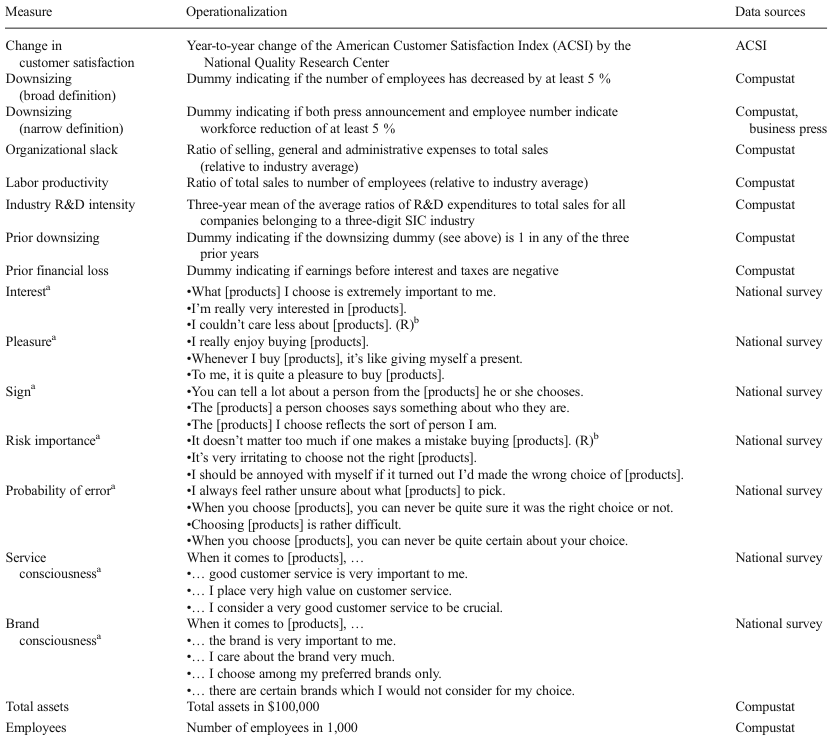

NOTE: complex table shown as an image of the PDF; the text below is a rough machine extraction and may be mis-aligned.

**extracted text (unreliable layout)**

(R) Item reverse coded

a 7-point Likert scales anchored “fully disagree” to “fully agree”

b Item dropped due to low factor loading

J. of the Acad. Mark. Sci. (2015) 43:768–789 779

Page 13

Table 5 Descriptive statistics and correlations for the customer satisfaction model

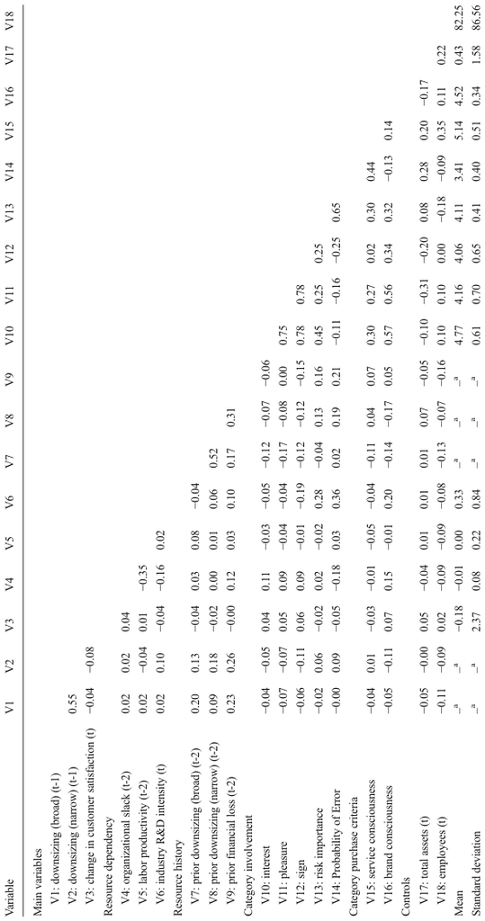

NOTE: complex table shown as an image of the PDF; the text below is a rough machine extraction and may be mis-aligned.

**extracted text (unreliable layout)**

Note: p<0.05 for |r|>0.08; p<0.01 for |r|>0.10; p<0.001 for |r|>0.13 (based on two-tailed tests)

a Dummy variable

780 J. of the Acad. Mark. Sci. (2015) 43:768–789

Page 14

In H1 we predict that organizational slack positively moderates the effect of downsizing on customer satisfaction. The corresponding interaction term is positive and significant both for the cutoff 2007 (β9=6.17, p<0.05) and 2006 (β9=6.55, p<0.05), providing support for H1

Hypothesis 2 posits that labor productivity negatively moderates the downsizing–satisfaction link. In support of H2, the interaction between labor productivity and downsizing has a significant negative effect using both the cutoff 2007 (β10= −1.90, p<0.01) and 2006 (β10=−1.83, p<0.01).

H3 suggests that industry R&D intensity negatively moderates the downsizing–customer satisfaction chain. This hypothesis is strongly supported both for the cutoff 2007 (β11= −0.82, p<0.001) and 2006 (β11=−1.00, p<0.001).

In H4 we propose that downsizing has a more deleterious effect on change in customer satisfaction for firms that undergo repeated downsizing. While, consistent with this proposition, the interaction term between downsizing and prior downsizing is negative, it is insignificant both for the cutoff 2007 and 2006. Hence, H4 is not supported by the data. Similarly, we do not find support for H5: the sign of the interaction coefficient between downsizing and prior financial loss is positive as proposed, but insignificant.

Regarding product category involvement, we do not find support for H6 through H8 as the interaction coefficients are insignificant. Hypotheses 9 and 10 are supported. In line with our propositions, the interaction coefficient between downsizing and risk importance is significantly negative

Table 6 Customer satisfaction model (Broad Downsizing Operationalization)

|  |  | Dependentvariable:changeincustomersatisfaction(t) |  |  |  |  |
| --- | --- | --- | --- | --- | --- | --- |
|  |  | Model1 | Model2 |  | Model3 | Model4 |
|  |  | Fixedeffectswith Fixedeffectswith clusterederrorsa clusterederrorsa |  |  | Fixedeffects GL Sb | Fixedeffects GL Sb |
| Variable |  | Cutoffyear2007 Cutoffyear2006 |  |  | Cutoffyear2007 | Cutoffyear2006 |
| Downsizing (t-1) |  | −0 .97 | (0 .32)** −0 .96 | (032)** . | −1 .00 (0 .17)*** | −1 .29 (0 .24)*** |
| Organizational slack (t-2) |  | 110 . | (141)n.s. 008 . . | (179)n.s. . | −1 .56 (0 .59)** | 125 (133)n.s. . . |
| Labor productivity (t-2) |  | 102 . | (073)n.s. 055 . . | (092)n.s. . | −0 .64 (0 .25)** | 014 (060)n.s. . . |
| IndustryR&Dintensity(t) |  | −0 .17 | (0 .11)n.s. −0 .11 | (013)n.s. . | −0 .30 (0 .04)*** | −0 .14 (0 .09)n.s. |
| Prior downsizing (t-2) |  | −0 .09 | (017)n.s. 000 . . | (019)n.s. . | −0 .68 (0 .08)*** | −0 .19 (0 .11)n.s. |
| Prior financial loss (t-2) |  | 124 . | (089)n.s. 188 . . | (083)* . | 070 (048)n.s. . . | 230 (060)*** . . |
| Totalassets(t) |  | 001 . | (011)n.s. 011 . . | (007)n.s. . | 007 (002)*** . . | 019 (004)*** . . |
| Employees(t) |  | 000 . | (0 .00)n.s. −0 .00 | (000)n.s. . | −0 .00 (0 .00)n.s. | −0 .00 (0 .00)n.s. |
| Downsizing (t-1) × organizational slack (t-2) | H1:+ | 617 . | (271)* 655 . . | (302)* . | −1 .96 (1 .02)n.s. | 600 (243)* . . |
| Downsizing (t-1) × labor productivity (t-2) | H2:− | −1 .90 | (0 .66)** −1 .83 | (061)** . | −5 .39 (0 .70)*** | −1 .98 (0 .70)** |
| Downsizing (t-1) × industry R&D intensity (t) H3:− |  | −0 .82 | (0 .18)*** −1 .00 | (019)*** . | −0 .28 (0 .09)** | −1 .29 (0 .18)*** |
| Downsizing (t-1) × prior downsizing (t-2) | H4:− | −0 .14 | (0 .42)n.s. −0 .21 | (044)n.s. . | −0 .28 (0 .15)n.s. | 042 (031)n.s. . . |
| Downsizing (t-1) × prior financial loss (t-2) | H5:+ | 114 . | (119)n.s. 114 . . | (108)n.s. . | 280 (062)*** . . | 159 (084)n.s. . . |
| Downsizing (t-1) × interest | H6:− | 016 . | (074)n.s. 089 . . | (092)n.s. . | 177 (031)*** . . | 159 (062)* . . |
| Downsizing (t-1) × pleasure | H7:− | 041 - . | (0 .59)n.s. -0 .50 | (063)n.s. . | −0 .09 (0 .32)n.s. | −1 .26 (0 .51)* |
| Downsizing (t-1) × sign | H8:+ | 081 . | (067)n.s. 041 . . | (073)n.s. . | 051 (028)n.s. . . | 082 (055)n.s. . . |
| Downsizing (t-1) × risk importance | H9:− | −2 .48 | (0 .89)** −2 .85 | (108)** . | −2 .93 (0 .32)*** | −3 .24 (0 .75)*** |
| Downsizing (t-1) × probability of error | H10:+ | 392 . | (110)*** 451 . . | (130)*** . | 194 (049)*** . . | 444 (090)*** . . |
| Downsizing (t-1) × service consciousness | H11:− | −0 .51 | (0 .58)n.s. −0 .94 | (071)n.s. . | −1 .73 (0 .29)*** | −0 .91 (0 .49)n.s. |
| Downsizing (t-1) × brand consciousness | H12:+ | 177 . | (084)* 178 . . | (099)n.s. . | 146 (029)*** . . | 199 (062)** . . |
| Yeardummiesc |  | Included | Included |  | Included | Included |
| Numberoffirms |  | 110 | 105 |  | 110 | 105 |
| Number of firm-years |  | 710 | 637 |  | 710 | 637 |
| Numberofdownsizingevents |  | 153 | 139 |  | 153 | 139 |
| R2 (within) |  | 015 . | 017 . |  | 008 . | 024 . |

NOTE: table converted from PDF layout to HTML text; cell boundaries are reconstructed. See PDF if exact alignment matters.

n.s. p>0.05; * p<0.05; ** p<0.01; *** p<0.001 (based on two-tailed tests)

Notes: Unstandardized parameters are shown. Standard errors are in parentheses

a Estimated with STATA (version 10.1), procedure xtreg

b Estimated with R (version 3.0.2), procedure pggls (version 1.4–0)

c Dummy variable for each year was included in the models in order to account for fixed effects on the time level

J. of the Acad. Mark. Sci. (2015) 43:768–789 781

Page 15

(cutoff 2007: β17=−2.48, p<0.01; cutoff 2006: β17=−2.85, p<0.01), whereas the interaction coefficient between downsizing and probability of error is significantly positive (cutoff 2007: β18=3.92, p<0.001; cutoff 2006: β18=4.51, p<0.001).

Regarding product category purchase criteria, there is no evidence in support of H11. Service consciousness does not have a significant interaction effect with downsizing. Concerning H12, brand consciousness positively moderates the effect of downsizing on change in customer satisfaction for the cutoff 2007 (β20=1.77, p<0.05). When choosing the cutoff 2006, the interaction effect is insignificant. Hence, support for H12 is limited.

Models 3 and 4 are estimated using the fixed effects GLS method as an alternative estimator. Here, in line with models 1 and 2, the moderating effects of labor productivity (H2), industry R&D intensity (H3), risk importance (H9), and probability of error (H10) are supported, whereas the moderating effects of prior downsizing (H4) and sign (H8) are not. The strong consistency across all four models raises our confidence in the validity of these findings. Moreover, in line with model 1, the moderating effect of brand consciousness is supported. The interaction effect of organizational slack is significant in model 4 but insignificant in model 3. Hence, seeing that the interaction coefficients of brand consciousness and organizational slack are significant in three out of four models, in summary we find some support for H1 and H12. Lastly, H5, H6, H7, and H11 are partly supported in at least one of models 3 and 4, making our result in their regard somewhat inconclusive.

Robustness checks for different operationalizations of downsizing

Second, we tested the stability of the results when using other values than 5 % as a cutoff-point for downsizing events. We find highly consistent results for cutoff points of 4 to 7 %. Moreover, for a 3 % cutoff point, many effects just barely lose their statistical significance. This might indicate that at a 3 % cutoff point, the effects of downsizing dilute somewhat. Despite that, overall we are confident that our results are stable for cutoff-points ranging from 3 to 7 %. For more extreme cutoff points (e.g., 1, 10, or 15 %) the pattern of results is visibly affected.

Indirect effect of downsizing on financial performance via customer satisfaction

To examine our proposition that customer satisfaction mediates the effect of downsizing on financial performance, we conducted a mediation analysis. Therefore, we specified a model with change in financial performance as the dependent variable, operationalized as return on assets (ROA) in t minus ROA in t-1. ROA is calculated as the ratio of earnings before interest, taxes, depreciation and amortization to total assets. This operationalization is widely used in downsizing research (e.g., Bruton et al. 1996; Guthrie and Datta 2008; Love and Nohria 2005). As Cascio, Young, and Morris (1997: 1177) argue: “Any changes in the performance of a firm that result from employment downsizing should show up in the ROA measure.” As independent variables, we included our prior independent variables lagged by one additional period. We further included organizational slack and labor productivity in t as additional control variables.

Table 8 shows the results. Model 1 reports the effect of downsizing on change in financial performance without controlling for change in customer satisfaction. The effect is not statistically significant. In model 2, we added change in customer satisfaction in t-1 as an independent variable. Again, we find no effect of downsizing on financial performance, whereas—consistent with much earlier research (e.g., Anderson et al. 1994; Anderson et al. 2004)—change in customer satisfaction has a positive

782 J. of the Acad. Mark. Sci. (2015) 43:768–789

Page 16

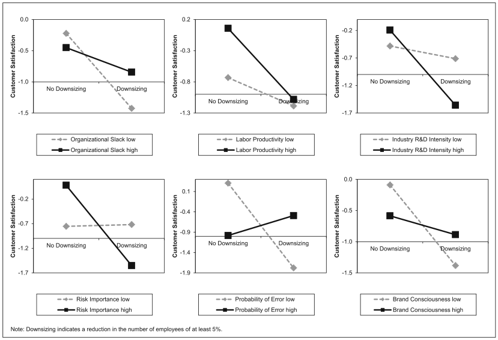

NOTE: figure/graphic rendered as an image from the PDF; its content is not machine-readable text. Caption (if any) follows as the next block.

effect (βCS→ROA=0.17, p<0.05). As a robustness check, model 3 shows how the absolute level of customer satisfaction (instead the year-to-year change) affects return on assets. We find a strong positive effect (βCS→ROA=0.57, p<0.001), which substantiates our finding that customer satisfaction is positively linked to financial performance.

The fact that downsizing reduces customer satisfaction and that customer satisfaction drives financial performance points to a potential indirect effect of downsizing on financial performance via customer satisfaction in line with H13. To test H13, we conducted the Sobel test (Sobel 1982), finding a significant effect (βDS→CS × βCS→ROA=−0.17, p<0.05). Hence, in support of H13 downsizing reduces customer satisfaction, which then reduces financial performance.

Table 9 analyzes this indirect effect for unfavorable conditions of our supported moderators. Following Spiller et al. (2013), we estimated the simple effect of downsizing on satisfaction for different levels of the moderators and then repeated the Sobel test. The negative indirect effect of downsizing on performance via satisfaction becomes stronger for companies with low slack or high labor productivity and in industries with high R&D intensity

as well as in product categories that customers perceive as risky but have a low probability of error.

Discussion

Research implications

Downsizing has been a popular managerial instrument for almost 30 years. However, only recently have researchers started to look at customer outcomes of downsizing. Our research contributes to this new research stream in several ways.

Previous research on customer outcomes of downsizing has focused on B2B markets (e.g., Lewin 2009; Lewin and Johnston 2008; Lewin et al. 2010). We extend the field by looking at B2C markets. Here, we also find that downsizing reduces customer satisfaction. We argue that this finding is less intuitive than it maybe sounds. In B2B markets there is typically a strong degree of personal interaction between customers and employees of the downsizing supplier. In contrast, in most B2C markets, consumers have little to no personal contact with firm employees. As a result, in many product categories consumers seem to be indifferent to

Fig. 2 Interaction plots

J. of the Acad. Mark. Sci. (2015) 43:768–789 783

Page 17

employee working conditions. For instance, despite the highly publicized problems of workers in one of Apple’s supplier firms (e.g., Mishkin 2013), in October 2013 Apple CEO Tim Cook reported that Apple was winning in terms of customer satisfaction (Bradshaw 2013).

In light of this potential consumer indifference to the way products and services are produced, the question becomes: When does downsizing affect satisfaction? Our findings indicate that consumers mostly respond to downsizing if it results in noticeable deteriorations of product performance. Only in firms with resource configurations that make them especially vulnerable to losses of human capital (high R&D intensity, high labor productivity, little slack), does downsizing affect

customer outcomes. Moreover, if customers have difficulties in evaluating product quality, downsizing does not reduce satisfaction. Similarly, downsizing has little to no effect if customers rely on brands as primary cue in purchasing decisions. Thus, in B2C markets the effect of downsizing on satisfaction is indeed less clearcut than one would maybe expect.

That said, some of our moderator hypotheses were not supported by the data. For instance, whether services play an important role in a product category does not affect the downsizing-satisfaction link. This is interesting because Anderson et al. (1997) argue that there is a larger trade-off between productivity and customer satisfaction for service companies than for manufacturers. Their argument is based

Table 7 Customer satisfaction model (Narrow Downsizing Operationalization)

|  | Dependentvariable:changeincustomersatisfaction(t) |  |
| --- | --- | --- |
|  | Model1 | Model2 |
|  | Fixedeffectswithclusterederrorsa FixedeffectsGLSb |  |
| Variable | Cutoffyear2007 | Cutoffyear2007 |
| Downsizing (t-1) | −1 .67 | (0 .32)*** −1 .94 (0 .40)*** |
| Organizational slack (t-2) | 060 . | (1 .34)n.s. −0 .52 (0 .96)n.s. |
| Labor productivity (t-2) | 074 . | (0 .59)n.s. −0 .09 (0 .43)n.s. |
| IndustryR&Dintensity(t) | 000 . | (0 .11)n.s. −0 .13 (0 .08)n.s. |
| Prior downsizing (t-2) | 007 . | (0 .24)n.s. −0 .14 (0 .13)n.s. |
| Prior financial loss (t-2) | 113 . | (074)n.s. 094 (048)n.s. . . . |
| Totalassets(t) | 000 . | (09)n.s. 007 (003)** . . |
| Employees(t) | 000 . | (0 .00)n.s. −0 .00 (0 .00)n.s. |
| Downsizing (t-1) × organizational slack (t-2) H1:+ | 684 . | (5 .22)n.s. −2 .40 (3 .89)n.s. |
| Downsizing (t-1) × labor productivity (t-2) H2:− | −2 .45 | (1 .77)n.s. −1 .92 (1 .55)n.s. |
| Downsizing (t-1) × industry R&D intensity (t) H3:− | −1 .17 | (0 .19)*** −0 .58 (0 .18)** |
| Downsizing (t-1) × prior downsizing (t-2) H4:− | −0 .77 | (093)n.s. 054 (066)n.s. . . . |
| Downsizing (t-1) × prior financial loss (t-2) H5:+ | −0 .40 | (0 .97)n.s. −0 .88 (0 .75)n.s. |
| Downsizing (t-1) × interest H6:− | 628 . | (293)* 599 (273)* . . . |
| Downsizing (t-1) × pleasure H7:− | −0 .71 | (0 .94)n.s. −1 .08 (0 .88)n.s. |
| Downsizing (t-1) × sign H8:+ | −2 .39 | (1 .59)n.s. −0 .56 (1 .66)n.s. |
| Downsizing (t-1) × risk importance H9:− | −2 .03 | (1 .24)n.s. −5 .65 (1 .54)*** |
| Downsizing (t-1) × probability of error H10:+ | 777 . | (263)** 1021 (226)*** . . . |
| Downsizing (t-1) × service consciousness H11:− | −3 .13 | (1 .62)n.s. −1 .50 (1 .50)n.s. |
| Downsizing (t-1) × brand consciousness H12:+ | −2 .48 | (3 .11)n.s. −3 .21 (2 .77)n.s. |
| Yeardummiesc | Included | Included |
| Numberoffirms | 110 | 110 |
| Number of firm-years | 710 | 710 |
| Numberofdownsizingevents | 54 | 54 |
| R2 (within) | 015 . | 020 . |

NOTE: table converted from PDF layout to HTML text; cell boundaries are reconstructed. See PDF if exact alignment matters.

n.s. p>0.05; * p<0.05; ** p<0.01; *** p<0.001 (based on two-tailed tests)

Unstandardized parameters are shown. Standard errors are in parentheses

a Estimated with STATA (version 10.1), procedure xtreg

b Estimated with R (version 3.0.2), procedure pggls (version 1.4–0)

c Dummy variable for each year was included in the models in order to account for fixed effects on the time level

784 J. of the Acad. Mark. Sci. (2015) 43:768–789

Page 18

on the observation that customization is more important in service firms, which reduces possibilities for increasing productivity. Given the increasing importance of customizing manufactured goods, differences between service firms and manufacturers may have become smaller in this regard.

Likewise, we do not find that downsizing is less harmful to customer satisfaction if firm financial performance was declining before the downsizing or if a firm had downsized before. This is noteworthy because past performance explains image effects of downsizing. Love and Kraatz (2009) report that negative effects of downsizing on firm image are less pronounced if the downsizing is a response to performance

problems. The different results points to the importance of distinguishing between image and satisfaction as outcomes of downsizing.

The way our study is designed also extends earlier research methodologically: (1) Previous research on customer outcomes of downsizing used cross-sectional data, which triggers reverse causality issues. It is possible that low customer satisfaction forces firms to cut costs through downsizing. This would also entail a negative correlation between downsizing and satisfaction. By linking satisfaction to downsizing the year before, our setup alleviates these concerns. (2) Previous research has relied on single-source data from a customer’s perspective (e.g., Lewin 2009; Lewin and Johnston 2008; Lewin et al. 2010) or

Table 8 Financial performance model

| Variable | Dependentvariable: |  | Dependentvariable: |  | Dependentvariable: |  |
| --- | --- | --- | --- | --- | --- | --- |
|  | changeinreturnonassets(t) |  | changeinreturnonassets(t) |  | returnonassets(t) |  |
|  | Model1 |  | Model2 |  | Model3 |  |
| Change in customer satisfaction (t-1) | – |  | 017 . | (007)* . | – |  |
| Customer satisfaction (t-1) | – |  | – |  | 057 . | (014)*** . |
| Downsizing (t-2) | −0 .12 | (099)n.s. . | 004 . | (099)n.s. . | 107 . | (071)n.s. . |
| Organizational slack (t-3) | −2 .35 | (486)n.s. . | −2 .43 | (496)n.s. . | −6 .26 | (509)n.s. . |
| Organizationalslack(t) | −6 .47 | (537)n.s. . | −6 .86 | (538)n.s. . | −6 .74 | (1677)n.s. . |
| Labor productivity (t-3) | −7 .61 | (171)*** . | −7 .73 | (173)*** . | −9 .00 | (415)*. . |
| Laborproductivity(t) | 613 . | (133)*** . | 637 . | (135)*** . | 769 . | (241)**. . |
| Industry R&D intensity (t-1) | 030 . | (090)n.s. . | 033 . | (091)n.s. . | 024 . | (045)n.s. . |
| Prior downsizing (t-3) | 017 . | (030)n.s. . | 018 . | (030)n.s. . | 050 . | (042)n.s. . |
| Prior financial loss (t-3) | −0 .46 | (187)n.s. . | −0 .85 | (194)n.s. . | −2 .99 | (168)n.s. . |
| Total assets (t-1) | −0 .10 | (009)n.s. . | −0 .12 | (010)n.s. . | −0 .40 | (022)n.s. . |
| Employees (t-1) | 001 . | (000)n.s. . | 001 . | (000)n.s. . | −0 .01 | (001)n.s. . |
| Downsizing (t-2) × organizational slack (t-3) | 1124 . | (530)* . | 1014 . | (530)n.s. . | 150 . | (730)n.s. . |
| Downsizing (t-2) × labor productivity (t-3) | 034 . | (144)n.s. . | 068 . | (142)n.s. . | 212 . | (215)n.s. . |
| Downsizing (t-2) × industry R&D intensity (t-1) | 086 . | (060)n.s. . | 105 . | (058)n.s. . | 214 . | (067)** . |
| Downsizing (t-2) × prior downsizing (t-3) | −1 .42 | (094)n.s. . | −1 .39 | (093)n.s. . | −1 .18 | (100)n.s. . |
| Downsizing (t-2) × prior financial loss (t-3) | −2 .49 | (400)n.s. . | −2 .73 | (394)n.s. . | −1 .95 | (139)n.s. . |
| Downsizing (t-2) × interest | 055 . | (293)n.s. . | 036 . | (289)n.s. . | 116 . | (246)n.s. . |
| Downsizing (t-2) × pleasure | 115 . | (141)n.s. . | 126 . | (140)n.s. . | −1 .89 | (136)n.s. . |
| Downsizing (t-2) × sign | −1 .46 | (257)n.s. . | −1 .50 | (253)n.s. . | 056 . | (219)n.s. . |
| Downsizing (t-2) × risk importance | −0 .03 | (215)n.s. . | 044 . | (209)n.s. . | −1 .45 | (166)n.s. . |
| Downsizing (t-2) × probability of error | 164 . | (280)n.s. . | 084 . | (275)n.s. . | −0 .21 | (219)n.s. . |
| Downsizing (t-2) × service consciousness | −0 .48 | (190)n.s. . | −0 .28 | (185)n.s. . | −0 .76 | (155)n.s. . |
| Downsizing (t-2) × brand consciousness | 050 . | (234)n.s. . | 020 . | (230)n.s. . | −1 .74 | (188)n.s. . |
| Yeardummiesa | Included |  | Included |  | Included |  |
| Numberoffirms | 104 |  | 104 |  | 104 |  |
| Number of firm-years | 609 |  | 609 |  | 610 |  |
| R2 (within) | 011 . |  | 012 . |  | 023 . |  |

NOTE: table converted from PDF layout to HTML text; cell boundaries are reconstructed. See PDF if exact alignment matters.

n.s. p>0.05; *p<0.05; **p<0.01; ***p<0.001 (based on two-tailed tests)

Unstandardized parameters are shown. Standard errors are in parentheses. Estimation method: fixed effects with clustered errors, cutoff year 2007

a Dummy variable for each year was included in the models in order to account for fixed effects on the time level

J. of the Acad. Mark. Sci. (2015) 43:768–789 785

Page 19

a managerial perspective (Homburg et al. 2012). Our research integrates the two perspectives. Hence, with our design common method effects can probably be ruled out as an explanation for the negative downsizing–satisfaction link.

Finally, our study establishes that customer satisfaction following downsizing mediates the downsizing–performance relationship. By identifying this mechanism, it also contributes to research on the “hidden costs” of downsizing, i.e., costs that are often overlooked by managers starting these activities (Buono 2003). Furthermore, our study offers a new explanation why researchers have found it hard to find a consistent effect of downsizing on performance (e.g., Datta et al. 2010). If customer satisfaction mediates the effects of downsizing, interaction effects with context factors can create conflicting evidence with regard to the overall relationship. In fact, we too do not find a significant direct effect of downsizing on financial performance (see model 1 in Table 8). Coupled with our finding of an indirect effect via customer satisfaction, this suggests that multiple (opposing) indirect effects explain the relationship between downsizing and financial performance (e.g., MacKinnon et al. 2000; Rucker et al. 2011; Shrout and Bolger 2002).

It needs to be mentioned that when measuring downsizing, we follow a convention from management research. We consider any firm year as a downsizing year in which the number of employees went down by at least 5 %. This comes with limitations. First, the 5 % threshold is somewhat arbitrary. We find that results are mostly robust for other thresholds in a range between 3 and 7 %. For very high threshold values (e.g., 15 %), results differ. Therefore, future research could analyze extreme downsizing events further. Second, large reductions of the number of employees may not always indicate layoffs. Results are qualitatively consistent if only downsizing activities covered in the press are considered. Third, the operationalization of downsizing is very general. Maybe outcomes of downsizing differ depending on the department

affected. Future research could compare downsizing consequences between departments.

Managerial implications

Our study has important implications for managers. Managers must be aware that depending on their firm and product category, downsizing has differential effects on customers. Thus, managers should “think outside the firm” while implementing downsizing. Our results indicate that this might be worth the effort. Managers should be especially careful with downsizing if industry R&D intensity and labor productivity are high, while organizational slack is low. Similarly, they should actively consider alternatives to downsizing if customers perceive purchases in the category as risky, customers find it easy to assess product quality, and customers do not consider the brand an important purchase criterion.

Interestingly, our results suggest that currently managers do not pay much attention to these aspects when engaging in downsizing. A look at our Table 5 reveals that the correlations between the aforementioned variables and downsizing activity are all smaller than 0.10. Hence, it appears as if currently managers mostly ignore the detrimental effects of downsizing on customers. Our study could contribute to increasing the awareness for these issues.

In addition, our study can guide managers interested in reducing detrimental customer outcomes of downsizing. First, customers react more negatively to downsizing in product categories where purchases are perceived as risky. This points to the importance of managing customer perceived risk during a downsizing. For instance, marketing managers could consider offering additional guarantees to their customer (e.g., a satisfaction guarantee). They should also implement a communication strategy that transparently addresses potential concerns of the customers. Second, customers react less negatively to

Table 9 Mediation analysis

|  | β DS→CS |  | β DS→CS × β CS→ROA | Sobelteststatistic | p value (two-tailed) |
| --- | --- | --- | --- | --- | --- |
| Main model i .e average values for all moderators , . | −0 .97 | (032)** . | −0 .17 | −1 .98* | 0047 . |
| Loworganizationalslack | −1 .46 | (035)*** . | −0 .25 | −2 .21* | 0027 . |
| Highlaborproductivity | −1 .30 | (036)*** . | −0 .24 | −2 .15* | 0032 . |
| HighindustryR&Dintensity | −1 .66 | (037)*** . | −0 .29 | −2 .25* | 0025 . |
| Highriskimportance | −1 .99 | (049)*** . | −0 .34 | −2 .19* | 0028 . |
| Lowprobabilityoferror | −2 .54 | (058)*** . | −0 .44 | −2 .24* | 0025 . |
| Lowbrandconsciousness | −1 .57 | (053)** . | −0 .27 | −1 .95n.s. | 0051 . |
| Alloftheabove | −5 .76 | (107)*** . | −1 .00 | −2 .34* | 0019 . |

NOTE: table converted from PDF layout to HTML text; cell boundaries are reconstructed. See PDF if exact alignment matters.

n.s. p>0.05; *p<0.05; **p<0.01; ***p<0.001 (based on two-tailed tests)

DS, downsizing; CS, customer satisfaction; ROA, return on assets. Unstandardized parameters are shown. Standard errors are in parentheses. Estimation method: fixed effects with clustered errors, cutoff year 2007. Low/high values for moderators are calculated as one standard deviation below/above the mean value

786 J. of the Acad. Mark. Sci. (2015) 43:768–789

Page 20

downsizing in product categories where brands play an important role. Hence, during downsizing, marketers should put particular emphasis on brand communication at the point of sale and elsewhere.

Limitations

This study does have several limitations. First, it relies on balance sheet data to measure firm-related variables. Hence, downsizing is measured through a proxy, which—as discussed before—is tied to a number of assumptions about the nature of downsizing. We provide evidence that results are relatively stable if other operationalizations are used, but these come with their own disadvantages. Second, the archival nature of the data has also to some extent guided and restricted our choice of firm-level moderators. Survey data could provide additional insights on how to manage downsizing, but data on sensitive issues like downsizing is notoriously difficult to obtain (Homburg et al. 2012) and not available for the time period of interest. Third, in terms of the firms analyzed, this study is subject to the inclusion requirements of the ACSI. It served as the starting point of our data collection efforts. Fourth, product category involvement is measured at one point in time after the focal time-period of the study. Thus, for our results concerning customer-related interactions to hold, it is required to assume that product category involvement is to some extent constant over time.

Conclusion

In the B2C markets covered by the American Customer Satisfaction Index, organizational downsizing is on average associated with decreases in customer satisfaction. In turn these customer outcomes of downsizing affect firm performance. However, the extent of negative customer reactions to downsizing is largely influenced by contextual variables. In particular, the degree to which a firm depends on human resources and the way customers process information in a product category moderate the downsizing-satisfaction link. Hence, in specific firm–product configurations, downsizing may prove detrimental with regard to customer satisfaction. For other firms, downsizing will not entail any negative customer response.

References

Ahmadjian, C. L., & Robinson, P. (2001). Safety in numbers: downsizing

and the deinstitutionalization of permanent employment in Japan. Administrative Science Quarterly, 46, 622–654.

Amabile, T. M., & Conti, R. (1999). Changes in the work environment for

creativity during downsizing. Academy of Management Journal, 42, 630–640. Anderson, E. W. (1994). Cross-category variation in customer satisfaction

and retention. Marketing Letters, 5, 19–30. Anderson, E. W. (1996). Customer satisfaction and price tolerance.

Marketing Letters, 7, 265–274. Anderson, E. W., & Mansi, S. A. (2009). Does customer satisfaction

matter to investors? Findings from the bond market. Journal of Marketing Research, 46, 703–714. Anderson, E. W., Fornell, C., & Lehmann, D. R. (1994). Customer

satisfaction, market share, and profitability: findings from Sweden. Journal of Marketing, 68, 53–66. Anderson, E. W., Fornell, C., & Rust, R. T. (1997). Customer satisfaction,

productivity, and profitability: differences between goods and services. Marketing Science, 16, 129–145. Anderson, E. W., Fornell, C., & Mazvancheryl, S. K. (2004).

Customer satisfaction and shareholder value. Journal of Marketing, 68, 172–185. Arnold, M. J., & Reynolds, K. E. (2012). Approach and avoidance

motivation: investigating hedonic consumption in a retail setting. Journal of Retailing, 88, 399–411. Bagozzi, R. P., & Yi, Y. (1988). On the evaluation of structural equation

models. Journal of the Academy of Marketing Science, 16, 74–97. Baltagi, B. H. (2008). Econometric analysis of panel data.

Chichester: Wiley. Baltagi, B. H., & Li, Q. (1995). Testing AR(1) against MA(1) disturbances

in an error component model. Journal of Econometrics, 68, 133–151. Boulding, W., & Staelin, R. (1995). Identifying generalizable ef-

fects of strategic actions on firm performance: the case of demand-side returns to R&D spending. Marketing Science, 14, G222–G236. Bourgeois, L. J., III. (1981). On the measurement of organizational slack.

Academy of Management Review, 6, 29–39. Bradley, G. W. (1978). Self-serving biases in the attribution process: a

reexamination of the fact or fiction question. Journal of Personality and Social Psychology, 36, 56–71. Bradshaw, T. (2013). Apple upbeat over iPhone sales momentum.

Financial Times (28-October-2013), Retrieved March 17, 2014 from http://www.ft.com/intl/cms/s/0/a10a6100-400a-11e3-a890- 00144feabdc0.htmlLaxzz2wGOdvOnh. Brady, M. K., Cronin, J. J., Jr., Fox, G. L., & Roehmb, M. L. (2008).

Strategies to offset performance failures: the role of brand equity. Journal of Retailing, 84, 151–164. Breusch, T., & Pagan, A. R. (1980). The Lagrange multiplier test and its

applications to model specification in econometrics. Review of Economic Studies, 47, 239–253. Brockner, J., Greenberg, J., Brockner, A., Bortz, J., Davy, J., & Carter, C.

(1986). Layoffs, equity theory, and work performance: further evidence of the impact of survivor guilt. Academy of Management Journal, 29, 373–384. Brockner, J., Grover, S., O’Malley, M. N., Reed, T. F., & Glynn, M. A.

(1993). Threat of future layoffs, self-esteem, and Survivors’ reactions: evidence from the laboratory and the field. Strategic Management Journal, 14, 153–166. Brockner, J., Konovsky, M., Cooper-Schneider, R., Folger, R., Martin, C.

L., & Bies, R. J. (1994). The interactive effects of procedural justice and outcome negativity on the victims and survivors of job loss. Academy of Management Journal, 37, 397–409. Brockner, J., Spreitzer, G., Mishra, A., Hochwarter, W., Pepper, L., &

Weinberg, J. (2004). Perceived control as an antidote to the negative effects of layoffs on Survivors’ organizational commitment and job performance. Administrative Science Quarterly, 49, 76–100. Bruton, G. D., Keels, J. K., & Shook, C. L. (1996). Downsizing the firm:

answering the strategic questions. Academy of Management Executive, 10, 38–45.

J. of the Acad. Mark. Sci. (2015) 43:768–789 787

Page 21

Buono, A. F. (2003). The hidden costs and benefits of organizational

resizing activities. In K. P. de Meuse & M. L. Marks (Eds.), Resizing the organization: managing layoff, divestitures, and closings (pp. 306–346). San Francisco: Jossey-Bass. Cameron, A. C., & Trivedi, P. K. (2010). Microeconometrics using stata.

College Station: StataCorp. Cameron, K. S., Freeman, S. J., & Mishra, A. K. (1991). Best practices in

white-collar downsizing: managing contradictions. Academy of Management Executive, 5, 57–73. Cascio, W. F. (2005). Strategies for responsible restructuring. Academy of

Management Executive, 19, 39–50. Cascio, W. F., Young, C. E., & Morris, J. R. (1997). Financial conse-

quences of employment-change decisions in major U.S. corporations. Academy of Management Journal, 40, 1175–1189. Chadwick, C., Hunter, L. W., & Walston, S. L. (2004). Effects of

downsizing practices on the performance of hospitals. Strategic Management Journal, 25, 405–427. Cohen, J. B., & Basu, K. (1987). Alternative models of categorization:

toward a contingent processing framework. Journal of Consumer Research, 13, 455–472. Croissant, Y., & Millo, G. (2008). Panel data econometrics in R: the plm

package. Journal of Statistical Software, 27, 1–43. Datta, D. K., Gutrhie, J. P., Basuil, D., & Pandey, A. (2010). Causes and

effects of employee downsizing: a review and synthesis. Journal of Management, 36, 281–348. DiFonzo, N., & Bordia, P. (1998). A tale of Two corporations: managing

uncertainty during organizational change. Human Resource Management, 37, 295–303. Dougherty, D., & Bowman, E. H. (1995). The effects of organizational

downsizing on product innovation. California Management Review, 37, 28–44. Dowling, G. R., & Staelin, R. (1994). A model of perceived risk and

intended risk-handling activity. Journal of Consumer Research, 21, 119–134. Erdem, T., & Swait, J. (1998). Brand equity as a signaling phenomenon.

Journal of Consumer Psychology, 7, 131–157. Ferraro, R., Kirmani, A., & Matherly, T. (2013). Look at Me! look at Me!

conspicuous brand usage, self-brand connection, and dilution. Journal of Marketing Research, 50, 477–488. Flanagan, D. J., & O’Shaughnessy, K. C. (2005). The effect of

layoffs on firm reputation. Journal of Management, 31, 445– 463. Fornell, C. (1992). A national customer satisfaction barometer: the swed-

ish experience. Journal of Marketing, 56, 6–21. Fornell, C., Johnson, M. D., Anderson, E. W., Cha, J., & Everitt Bryant,

B. (1996). The American customer satisfaction index: nature, purpose, and findings. Journal of Marketing, 60, 7–18. Fournier, S. (1998). Consumers and their brands: developing relationship

theory in consumer research. Journal of Consumer Research, 24, 343–373. Freeman, S. J., & Cameron, K. S. (1993). Organizational downsizing: a

convergence and reorientation framework. Organization Science, 4, 10–29. Gandolfi, F. (2008). Learning from the past—downsizing lessons for

managers. Journal of Management Research, 8, 3–17. Greenglass, E., & Burke, R. J. (2001). Stress and the effects of hospital

restructuring in nurses. Canadian Journal of Nursing Research, 33, 93–108. Grewal, R., Chandrashekaran, M., & Citrin, A. V. (2010). Customer

satisfaction heterogeneity and shareholder value. Journal of Marketing Research, 47, 612–626. Gruca, T. S., & Rego, L. L. (2005). Customer satisfaction, cash flow, and

shareholder value. Journal of Marketing, 69, 115–130. Guthrie, J. P. (2001). High-Involvement Work Practices, Turnover, and

Productivity: Evidence from New Zealand. Academy of Management Journal, 44, 180–190.

Guthrie, J. P., & Datta, D. K. (2008). Dumb and Dumber: The Impact of

Downsizing on Firm Performance as Moderated by Industry Conditions. Organization Science, 19, 108–123. Havlovic, S. J., Bouthillette, F., & Van der Wal, R. (1998). Coping with

downsizing and job loss: lessons from the shaughnessy hospital closure. Canadian Journal of Administrative Science Revue Canadienne des Science de l’Administration, 15, 322–332. Henning-Thurau, T., Groth, M., Paul, M., & Gremler, D. D. (2006). Are

All Smiles Created Equal? How Emotional Contagion and Emotional Labor Affect Service Relationships. Journal of Marketing, 70, 58–73. Homburg, C., & Stock, R. (2004). The link between sales people’s job

satisfaction and customer satisfaction in a business-to-business context: a dyadic analysis. Journal of the Academy of Marketing Science, 32, 144–158. Homburg, C., Klarmann, M., & Staritz, S. (2012). Customer uncertainty

following downsizing: the effects of extent of downsizing and open communication. Journal of Marketing, 76, 112–129. Hoyer, W. D., & MacInnis, D. J. (2007). Consumer behavior. Houghton:

Houghton Mifflin Company. Hurley, R. F., & Hult, T. M. (1998). Innovation, market orientation, and

organizational learning: an integration and empirical examination. Journal of Marketing, 62, 42–54. Irwin, J. R., & McClelland, G. H. (2001). Misleading heuristics and

moderated multiple regression models. Journal of Marketing Research, 38, 100–109. Ittner, C., Larcker, D., & Taylor, D. (2009). The stock market’s pricing of

customer satisfaction. Marketing Science, 28, 836–835. Iverson, R. D., & Pullman, J. A. (2000). Determinants of voluntary

turnover and layoffs in an environment of repeated downsizing following a merger: an event history analysis. Journal of Management, 26, 977–1003. Johar, G., Birk, M., & Einwiller, S. (2010). How to save your brand in the

face of crisis. MIT Sloan Management Review, 51, 57–64. Kahnemann, D., Knetsch, J. L., & Thaler, R. H. (1986). Fairness

and the assumptions of economics. Journal of Business, 59, 285–300. Kapferer, J.-N., & Laurent, G. (1993). Further evidence on the consumer

involvement profile: five antecedents of involvement. Psychology and Marketing, 10, 347–355. Koch, M. J., & McGrath, R. G. (1996). Improving labor productivity:

human resource management policies do matter. Strategic Management Journal, 17, 335–354. Kozlenkova, I., Samaha, S., & Palmatier, R. (2014). Resource-based

theory in marketing. Journal of the Academy of Marketing Science, 42, 1–21. Lam, S. Y., Shankar, V., Erramilli, M. K., & Murthy, B. (2004). Customer

value, satisfaction, loyalty, and switching costs: an illustration from a business-to-business service context. Journal of the Academy of Marketing Science, 32, 293–311. Laurent, G., & Kapferer, J.-N. (1985). Measuring consumer involvement

profiles. Journal of Marketing Research, 22, 41–53. Lawler, E. E. (1992). The ultimate advantage: creating the high-

involvement organization. San Francisco: Jossey-Bass. Lewin, J. E. (2009). Business customers’satisfaction: what happens when

suppliers downsize? Industrial Marketing Management, 38, 283– 299. Lewin, J. E., & Johnston, W. J. (2008). The impact of supplier

downsizing on performance, satisfaction over time, and repurchase intentions. Journal of Business & Industrial Marketing, 23, 249–255. Lewin, J. E., Biemans, W., & Ulaga, W. (2010). Firm downsizing and

satisfaction among united states and european customers. Journal of Business Research, 63, 697–706. Liao, H. (2007). Do it right this time: the role of employee service

recovery performance in customer-perceived justice and customer

788 J. of the Acad. Mark. Sci. (2015) 43:768–789

Page 22

loyalty after service failures. Journal of Applied Psychology, 92, 475–489. Love, G. E., & Kraatz, M. (2009). Character, conformity, or the bottom

line? How and Why downsizing affected corporate reputation. Academy of Management Journal, 52, 314–335. Love, G. E., & Nohria, N. (2005). Reducing slack: the performance

consequences of downsizing by large industrial firms. Strategic Management Journal, 26, 1087–1108. MacKinnon, D. P., Krull, J. L., & Lockwood, C. M. (2000). Equivalence

of the mediation, confounding, and suppression effect. Prevention Science, 1, 173–181. Marks, M. L. (2003). Revitalization after resizing. In K. P. de Meuse & M.

L. Marks (Eds.), Resizing the organization: managing layoff, divestitures, and closings (pp. 275–305). San Francisco: Jossey-Bass. Maxham, J. G., III, & Netemeyer, R. G. (2002). A longitudinal study of

complaining Custorners’ evaluations of multiple service Faiiures and recovery efforts. Journal of Marketing, 66, 57–71. McElroy, J. C., Morrow, P. C., & Rude, S. C. (2001). Turnover and

organizational performance: a comparative analysis of the effects of voluntary, involuntary, and reduction-in-force turnover. Journal of Applied Psychology, 86, 1294–1299. Mishkin, S. (2013). Apple Supplier Accused of Labour Violations.

Financial Times (23-July-2013). Retrieved March 17, 2014 from http://www.ft.com/intl/cms/s/0/ddc0ea56-f820-11e2-b4c4- 00144feabdc0.htmlLaxzz2wGOdvOnh. Mishra, A. K., & Spreitzer, G. M. (1998). Explaining How survivors

respond to downsizing: the roles of trust, empowerment, justice, and work redesign. Academy of Management Review, 23, 567–588. Mittal, V., & Kamakura, W. A. (2001). Satisfaction, repurchase intent,

and repurchase behavior: investigating the moderating effect of customer characteristics. Journal of Marketing Research, 38, 131– 142. Moore, S., Grunberg, L., & Greenberg, E. (2004). Repeated downsizing

contact: the effects of similar and dissimilar layoff experiences on work and well-being outcomes. Journal of Occupational Health Psychology, 9, 247–257. Nixon, R. D., Hitt, M. A., Lee, H.-U., & Jeong, E. (2004). Market

reactions to announcements of corporate downsizing actions and implementation strategies. Strategic Management Journal, 25, 1121–1129. Oliver, R. L. (1997). Satisfaction: a behavioral perspective on the

consumer. New York: McGraw-Hill. Olivia, R., & Sterman, J. D. (2001). Cutting corners and working over-

time: quality erosion in the service industry. Management Science, 47, 894–914. Pfeffer, J., & Sutton, R. I. (2000). The knowing-doing gap—how smart

companies turn knowledge into action. Boston: Harvard Business School Press. Pol, E. (2012). The preponderant causes of the USA banking crisis 2007–

08. The Journal of Socio-Economics, 41, 519–528. Qantas (2014). Qantas Group Strategy Update. Retrieved March 17,

2014 from http://www.qantasnewsroom.com.au/media-releases/ qantas-group-strategy-update-2 Reichheld, F. F., & Sasser, W. E., Jr. (1990). Zero defections:

quality comes to services. Harvard Business Review, 68, 105–111. Rucker, D. D., Preacher, K. J., Tormala, Z. L., & Petty, R. E. (2011).

Mediation analysis in social psychology: current practices and new recommendations. Social and Personality Psychology Compass, 5, 359–371. Shrout, P. E., & Bolger, N. (2002). Mediation in experimental and

nonexperimental studies: new procedures and recommendations. Psychological Methods, 7, 422–445.

Sloot, L. M., Verhoef, P. C., & Franses, P. H. (2005). The impact of brand

equity and the hedonic level of products on consumer stock-out reactions. Journal of Retailing, 81, 15–34. Sobel, M. E. (1982). Asymptotic confidence intervals for indirect effects

in structural equation models. Sociological Methodology, 12(1), 290–312. Spiller, S. A., Fitzsimons, G. J., Lynch, J. G., Jr., & McClelland, G. H.

(2013). Spotlights, floodlights, and the magic number zero: simple Effeots tests in moderated regression. Journal of Marketing Research, 50, 277–288. Subramony, M., & Holtom, B. C. (2012). The long-term influence of

service employee attrition on customer outcomes and profits. Journal of Service Research, 15, 460–473. Sujan, M. (1985). Consumer knowledge: effects on evaluation strategies

mediating consumer judgments. Journal of Consumer Research, 12, 31–46. Swaminathan, V., Page, K. L., & Gürhan-Canli, Z. (2007). ‘My’ brand or

‘Our’ brand: the effects of brand relationship dimensions and selfconstrual on brand evaluations. Journal of Consumer Research, 34, 248–259. Sydow, J., Schreyögg, G., & Koch, J. (2009). Organizational path depen-

dence: opening the black box. Academy of Management Review, 34, 689–709. Tellis, G. J. (2013). Unrelenting innovation: How to create a

culture for market dominance (JB Warren Bennis Series). Hoboken: Wiley. Tsui, A. S., Pearce, J. L., Porter, L. W., & Tripoli, A. M. (1997).

Alternative approaches to the employee-organization relationship: does investment in employees pay off? Academy of Management Journal, 40, 1089–1121. Tuli, K. R., & Bharadwaj, S. G. (2009). Customer satisfaction and stock

returns risk. Journal of Marketing, 73, 184–197. Tushman, M., & Nadler, D. (1986). Organization for innovation.

California Management Review, 28, 74–92. Vergne, J.-P., & Durand, R. (2010). The missing link between the theory

and empirics of path dependence: conceptual clarification, testability issue, and methodological implications. Journal of Management Studies, 47, 736–759. Vyas, D. (2011). The timeliness of accounting write-downs by U.S.

Financial institutions during the financial crisis of 2007–2008. Journal of Accounting Research, 49, 823–860. Wagar, T. H. (1998). Exploring the consequences of workforce

reduction. Canadian Journal of Administrative Science, 15, 300–309. Waters, R. (2014). IBM braced for fresh US job cuts. Retrieved March 17,

2014 from http://www.ft.com/cms/s/0/46e9c74a-a0c4-11e3-a72c- 00144feab7de.htmlLaxzz2wDOcA8vZ. Williams, P., Khan, M. S., & Naumann, E. (2011). Customer dissatisfac-

tion and defection: the hidden costs of downsizing. Industrial Marketing Management, 40, 405–13. Wiseman, R. M., & Bromiley, P. (1996). Toward a model of risk in

declining organizations: an empirical examination of risk, performance and decline. Organization Science, 7, 524–543. Wooldridge, J. M. (2002). Econometric analysis of cross section and

panel data. Cambridge: Massachusetts Institute of Technology. Worrell, D. L., Davidson, W. N., III, & Sharma, V. M. (1991). Layoff

announcements and stockholder wealth. Academy of Management Journal, 34, 662–678. Wu, T. (2011). The U.S. Money market and the term auction facility in the

financial crisis of 2007–2009. Review of Economics and Statistics, 93, 617–631. Zyglidopoulos, S. C. (2005). The impact of downsizing on corporate

reputation. British Journal of Management, 16, 253–259.

J. of the Acad. Mark. Sci. (2015) 43:768–789 789